# Project: Investigate a Dataset - [No-show appointments]

- Introduction
- Data Wrangling
- Exploratory Data Analysis
- Conclusions

## Introduction

### Question(s) for Analysis

Could factors such as Scholarship,Age,SMS_received and Hipertension affect why Patient didn't show up for their Scheduled-Appountment?

```python
import numpy as np
import pandas as pd
import matplotlib.pyplot as plt
import seaborn as sns
% matplotlib inline
```

```python
# Upgrade pandas to use dataframe.explode() function.
!pip install --upgrade pandas==0.25.0
```

## Data Wrangling

```python
df = pd.read_csv('Database_No_show_appointments/noshowappointments-kagglev2-may-2016.csv')
df.head()
```

|  | PatientId | AppointmentID | Gender | ScheduledDay | AppointmentDay | Age | Neighbourhood | Scholarship | Hipertension | Diabetes | Alcoholism | Handcap | SMS_received | No-show |
| --- | --- | --- | --- | --- | --- | --- | --- | --- | --- | --- | --- | --- | --- | --- |
| 0 | 2.987250e+13 | 5642903 | F | 2016-04-29T18:38:08Z | 2016-04-29T00:00:00Z | 62 | JARDIM DA PENHA | 0 | 1 | 0 | 0 | 0 | 0 | No |
| 1 | 5.589978e+14 | 5642503 | M | 2016-04-29T16:08:27Z | 2016-04-29T00:00:00Z | 56 | JARDIM DA PENHA | 0 | 0 | 0 | 0 | 0 | 0 | No |
| 2 | 4.262962e+12 | 5642549 | F | 2016-04-29T16:19:04Z | 2016-04-29T00:00:00Z | 62 | MATA DA PRAIA | 0 | 0 | 0 | 0 | 0 | 0 | No |
| 3 | 8.679512e+11 | 5642828 | F | 2016-04-29T17:29:31Z | 2016-04-29T00:00:00Z | 8 | PONTAL DE CAMBURI | 0 | 0 | 0 | 0 | 0 | 0 | No |
| 4 | 8.841186e+12 | 5642494 | F | 2016-04-29T16:07:23Z | 2016-04-29T00:00:00Z | 56 | JARDIM DA PENHA | 0 | 1 | 1 | 0 | 0 | 0 | No |

This cell above helps to show how the columns of the Dataset are seperated.

### Data Cleaning

```python
df.info()
```

```
<class 'pandas.core.frame.DataFrame'>
RangeIndex: 110527 entries, 0 to 110526
Data columns (total 14 columns):
PatientId         110527 non-null float64
AppointmentID     110527 non-null int64
Gender            110527 non-null object
ScheduledDay      110527 non-null object
AppointmentDay    110527 non-null object
Age               110527 non-null int64
Neighbourhood     110527 non-null object
Scholarship       110527 non-null int64
Hipertension      110527 non-null int64
Diabetes          110527 non-null int64
Alcoholism        110527 non-null int64
Handcap           110527 non-null int64
SMS_received      110527 non-null int64
No-show           110527 non-null object
dtypes: float64(1), int64(8), object(5)
memory usage: 11.8+ MB
```

Gives an overview of the total number of rows(which can be use to identify any missing rows) and Columns including the names, non null values and datatypes of each column in the Dataset

```python
df['ScheduledDay'] = pd.to_datetime(df['ScheduledDay'])
```

This changes the datatype to datetime as use in real world and makes it easy to read.

```python
df['AppointmentDay'] = pd.to_datetime(df['AppointmentDay'])
```

This changes the datatype to datetime as use in real world and makes it easy to read.

```python
df.info()
```

```
<class 'pandas.core.frame.DataFrame'>
RangeIndex: 110527 entries, 0 to 110526
Data columns (total 14 columns):
PatientId         110527 non-null float64
AppointmentID     110527 non-null int64
Gender            110527 non-null object
ScheduledDay      110527 non-null datetime64[ns, UTC]
AppointmentDay    110527 non-null datetime64[ns, UTC]
Age               110527 non-null int64
Neighbourhood     110527 non-null object
Scholarship       110527 non-null int64
Hipertension      110527 non-null int64
Diabetes          110527 non-null int64
Alcoholism        110527 non-null int64
Handcap           110527 non-null int64
SMS_received      110527 non-null int64
No-show           110527 non-null object
dtypes: datetime64[ns, UTC](2), float64(1), int64(8), object(3)
memory usage: 11.8+ MB
```

To confirm the change from object to datetime

```python
df.rename({'No-show':'No_show'},axis = 1,inplace = True)
```

helps rename the heading of the column 'No-show' to 'No_show'which makes it acceptable when assign to a variable.

```python
df_No_show = df.query("No_show == 'Yes'")
```

This helps separate the Data of Patients that missed their appointment from those that attended.

```python
df_No_show
```

|  | PatientId | AppointmentID | Gender | ScheduledDay | AppointmentDay | Age | Neighbourhood | Scholarship | Hipertension | Diabetes | Alcoholism | Handcap | SMS_received | No_show |
| --- | --- | --- | --- | --- | --- | --- | --- | --- | --- | --- | --- | --- | --- | --- |
| 6 | 7.336882e+14 | 5630279 | F | 2016-04-27 15:05:12+00:00 | 2016-04-29 00:00:00+00:00 | 23 | GOIABEIRAS | 0 | 0 | 0 | 0 | 0 | 0 | Yes |
| 7 | 3.449833e+12 | 5630575 | F | 2016-04-27 15:39:58+00:00 | 2016-04-29 00:00:00+00:00 | 39 | GOIABEIRAS | 0 | 0 | 0 | 0 | 0 | 0 | Yes |
| 11 | 7.542951e+12 | 5620163 | M | 2016-04-26 08:44:12+00:00 | 2016-04-29 00:00:00+00:00 | 29 | NOVA PALESTINA | 0 | 0 | 0 | 0 | 0 | 1 | Yes |
| 17 | 1.479497e+13 | 5633460 | F | 2016-04-28 09:28:57+00:00 | 2016-04-29 00:00:00+00:00 | 40 | CONQUISTA | 1 | 0 | 0 | 0 | 0 | 0 | Yes |
| 20 | 6.222575e+14 | 5626083 | F | 2016-04-27 07:51:14+00:00 | 2016-04-29 00:00:00+00:00 | 30 | NOVA PALESTINA | 0 | 0 | 0 | 0 | 0 | 0 | Yes |
| 21 | 1.215484e+13 | 5628338 | F | 2016-04-27 10:50:45+00:00 | 2016-04-29 00:00:00+00:00 | 4 | CONQUISTA | 0 | 0 | 0 | 0 | 0 | 0 | Yes |
| 22 | 8.632298e+14 | 5616091 | M | 2016-04-25 13:29:16+00:00 | 2016-04-29 00:00:00+00:00 | 13 | CONQUISTA | 0 | 0 | 0 | 0 | 0 | 1 | Yes |
| 31 | 3.112849e+11 | 5628907 | M | 2016-04-27 12:07:14+00:00 | 2016-04-29 00:00:00+00:00 | 12 | NOVA PALESTINA | 1 | 0 | 0 | 0 | 0 | 0 | Yes |
| 44 | 2.741649e+11 | 5635414 | F | 2016-04-28 13:27:27+00:00 | 2016-04-29 00:00:00+00:00 | 78 | SÃO CRISTÓVÃO | 0 | 1 | 1 | 0 | 0 | 0 | Yes |
| 48 | 8.545415e+12 | 5618643 | F | 2016-04-26 07:19:49+00:00 | 2016-04-29 00:00:00+00:00 | 58 | SÃO CRISTÓVÃO | 0 | 0 | 0 | 0 | 0 | 1 | Yes |
| 49 | 9.223559e+13 | 5534656 | F | 2016-03-31 17:11:17+00:00 | 2016-04-29 00:00:00+00:00 | 27 | GRANDE VITÓRIA | 0 | 0 | 0 | 0 | 0 | 1 | Yes |
| 50 | 1.827172e+14 | 5534661 | F | 2016-03-31 17:12:45+00:00 | 2016-04-29 00:00:00+00:00 | 19 | GRANDE VITÓRIA | 0 | 0 | 0 | 0 | 0 | 1 | Yes |
| 51 | 4.694699e+13 | 5534635 | F | 2016-03-31 17:05:31+00:00 | 2016-04-29 00:00:00+00:00 | 23 | GRANDE VITÓRIA | 1 | 0 | 0 | 0 | 0 | 1 | Yes |
| 52 | 7.987570e+14 | 5534639 | F | 2016-03-31 17:06:17+00:00 | 2016-04-29 00:00:00+00:00 | 23 | GRANDE VITÓRIA | 1 | 0 | 0 | 0 | 0 | 1 | Yes |
| 56 | 4.751189e+14 | 5600005 | M | 2016-04-19 09:47:43+00:00 | 2016-04-29 00:00:00+00:00 | 12 | NOVA PALESTINA | 0 | 0 | 0 | 0 | 0 | 1 | Yes |
| 61 | 5.594636e+11 | 5626971 | F | 2016-04-27 08:53:09+00:00 | 2016-04-29 00:00:00+00:00 | 2 | NOVA PALESTINA | 0 | 0 | 0 | 0 | 0 | 0 | Yes |
| 76 | 6.549277e+12 | 5597643 | M | 2016-04-18 17:40:18+00:00 | 2016-04-29 00:00:00+00:00 | 28 | ANTÔNIO HONÓRIO | 0 | 0 | 0 | 0 | 0 | 0 | Yes |
| 79 | 9.912882e+13 | 5597673 | M | 2016-04-18 17:53:25+00:00 | 2016-04-29 00:00:00+00:00 | 67 | MARIA ORTIZ | 0 | 0 | 0 | 0 | 0 | 1 | Yes |
| 90 | 8.782530e+14 | 5595362 | M | 2016-04-18 12:33:05+00:00 | 2016-04-29 00:00:00+00:00 | 11 | JUCUTUQUARA | 0 | 0 | 0 | 0 | 0 | 1 | Yes |
| 104 | 3.326985e+12 | 5632495 | F | 2016-04-28 08:04:48+00:00 | 2016-04-29 00:00:00+00:00 | 0 | SANTO ANTÔNIO | 0 | 0 | 0 | 0 | 0 | 0 | Yes |
| 107 | 7.954396e+12 | 5608249 | F | 2016-04-20 13:30:12+00:00 | 2016-04-29 00:00:00+00:00 | 26 | SANTO ANTÔNIO | 0 | 0 | 0 | 0 | 0 | 1 | Yes |
| 116 | 4.673335e+12 | 5574680 | F | 2016-04-12 15:35:30+00:00 | 2016-04-29 00:00:00+00:00 | 18 | SANTO ANTÔNIO | 0 | 0 | 0 | 0 | 0 | 1 | Yes |
| 123 | 3.673278e+13 | 5621388 | F | 2016-04-26 10:12:46+00:00 | 2016-04-29 00:00:00+00:00 | 31 | BELA VISTA | 1 | 0 | 0 | 0 | 0 | 1 | Yes |
| 126 | 9.447582e+14 | 5633576 | F | 2016-04-28 09:37:22+00:00 | 2016-04-29 00:00:00+00:00 | 67 | PRAIA DO SUÁ | 0 | 0 | 1 | 0 | 0 | 0 | Yes |
| 128 | 9.488697e+14 | 5571842 | F | 2016-04-12 09:41:01+00:00 | 2016-04-29 00:00:00+00:00 | 34 | PRAIA DO SUÁ | 1 | 0 | 0 | 0 | 0 | 1 | Yes |
| 129 | 5.537367e+13 | 5560735 | F | 2016-04-08 09:28:50+00:00 | 2016-04-29 00:00:00+00:00 | 22 | PRAIA DO SUÁ | 0 | 0 | 0 | 0 | 0 | 1 | Yes |
| 131 | 4.755938e+13 | 5637150 | M | 2016-04-28 17:38:06+00:00 | 2016-04-29 00:00:00+00:00 | 29 | PRAIA DO SUÁ | 0 | 0 | 0 | 1 | 0 | 0 | Yes |
| 132 | 8.468587e+14 | 5560742 | M | 2016-04-08 09:29:23+00:00 | 2016-04-29 00:00:00+00:00 | 0 | PRAIA DO SUÁ | 0 | 0 | 0 | 0 | 0 | 1 | Yes |
| 135 | 7.611590e+12 | 5560758 | M | 2016-04-08 09:30:58+00:00 | 2016-04-29 00:00:00+00:00 | 30 | PRAIA DO SUÁ | 0 | 0 | 0 | 0 | 0 | 1 | Yes |
| 136 | 3.428312e+12 | 5587516 | F | 2016-04-15 08:45:32+00:00 | 2016-04-29 00:00:00+00:00 | 33 | BONFIM | 1 | 0 | 0 | 0 | 0 | 1 | Yes |
| ... | ... | ... | ... | ... | ... | ... | ... | ... | ... | ... | ... | ... | ... | ... |
| 110383 | 2.957279e+12 | 5582577 | F | 2016-04-14 09:37:34+00:00 | 2016-06-01 00:00:00+00:00 | 48 | RESISTÊNCIA | 0 | 1 | 0 | 0 | 0 | 0 | Yes |
| 110385 | 7.631646e+13 | 5597360 | F | 2016-04-18 16:18:19+00:00 | 2016-06-08 00:00:00+00:00 | 23 | RESISTÊNCIA | 0 | 0 | 0 | 0 | 0 | 0 | Yes |
| 110386 | 2.957279e+12 | 5582576 | F | 2016-04-14 09:37:34+00:00 | 2016-06-01 00:00:00+00:00 | 48 | RESISTÊNCIA | 0 | 1 | 0 | 0 | 0 | 1 | Yes |
| 110391 | 2.529386e+14 | 5726417 | F | 2016-05-20 13:41:05+00:00 | 2016-06-06 00:00:00+00:00 | 19 | RESISTÊNCIA | 0 | 0 | 0 | 0 | 0 | 1 | Yes |
| 110392 | 9.844342e+14 | 5746278 | M | 2016-05-30 13:43:24+00:00 | 2016-06-07 00:00:00+00:00 | 38 | RESISTÊNCIA | 0 | 0 | 0 | 0 | 0 | 1 | Yes |
| 110394 | 6.994145e+13 | 5637132 | F | 2016-04-28 17:29:26+00:00 | 2016-06-07 00:00:00+00:00 | 31 | RESISTÊNCIA | 0 | 0 | 0 | 0 | 0 | 1 | Yes |
| 110399 | 9.437123e+13 | 5692938 | F | 2016-05-12 16:47:53+00:00 | 2016-06-07 00:00:00+00:00 | 17 | RESISTÊNCIA | 0 | 1 | 0 | 0 | 0 | 1 | Yes |
| 110400 | 8.382848e+11 | 5739407 | F | 2016-05-25 13:29:23+00:00 | 2016-06-07 00:00:00+00:00 | 36 | RESISTÊNCIA | 1 | 0 | 0 | 0 | 0 | 1 | Yes |
| 110401 | 9.291759e+12 | 5640506 | M | 2016-04-29 10:51:13+00:00 | 2016-06-07 00:00:00+00:00 | 39 | SANTOS REIS | 0 | 0 | 0 | 0 | 0 | 1 | Yes |
| 110402 | 5.387257e+13 | 5674212 | M | 2016-05-09 10:37:11+00:00 | 2016-06-07 00:00:00+00:00 | 38 | RESISTÊNCIA | 0 | 0 | 0 | 0 | 0 | 1 | Yes |
| 110405 | 2.758290e+14 | 5731069 | F | 2016-05-24 09:30:36+00:00 | 2016-06-06 00:00:00+00:00 | 33 | RESISTÊNCIA | 0 | 0 | 0 | 0 | 0 | 1 | Yes |
| 110415 | 6.717885e+13 | 5658645 | M | 2016-05-04 11:29:17+00:00 | 2016-06-06 00:00:00+00:00 | 59 | RESISTÊNCIA | 0 | 0 | 0 | 0 | 0 | 0 | Yes |
| 110420 | 2.934141e+12 | 5574038 | F | 2016-04-12 14:01:07+00:00 | 2016-06-06 00:00:00+00:00 | 41 | RESISTÊNCIA | 0 | 0 | 0 | 0 | 0 | 1 | Yes |
| 110428 | 9.167383e+12 | 5771346 | F | 2016-06-03 12:33:46+00:00 | 2016-06-08 00:00:00+00:00 | 8 | RESISTÊNCIA | 0 | 0 | 0 | 0 | 0 | 1 | Yes |
| 110429 | 1.664180e+14 | 5781902 | F | 2016-06-07 10:12:25+00:00 | 2016-06-08 00:00:00+00:00 | 44 | RESISTÊNCIA | 0 | 0 | 0 | 0 | 0 | 0 | Yes |
| 110430 | 4.986163e+13 | 5736999 | F | 2016-05-25 09:01:33+00:00 | 2016-06-01 00:00:00+00:00 | 57 | RESISTÊNCIA | 0 | 0 | 0 | 0 | 0 | 0 | Yes |
| 110431 | 2.175329e+12 | 5769362 | M | 2016-06-03 08:45:25+00:00 | 2016-06-08 00:00:00+00:00 | 12 | RESISTÊNCIA | 0 | 0 | 0 | 0 | 0 | 1 | Yes |
| 110432 | 1.269372e+12 | 5769371 | F | 2016-06-03 08:45:57+00:00 | 2016-06-08 00:00:00+00:00 | 34 | RESISTÊNCIA | 0 | 0 | 0 | 0 | 0 | 1 | Yes |
| 110442 | 7.167947e+13 | 5703900 | M | 2016-05-16 14:41:52+00:00 | 2016-06-06 00:00:00+00:00 | 8 | RESISTÊNCIA | 0 | 0 | 0 | 0 | 0 | 1 | Yes |
| 110449 | 2.911460e+14 | 5749879 | F | 2016-05-31 08:19:23+00:00 | 2016-06-06 00:00:00+00:00 | 12 | RESISTÊNCIA | 0 | 0 | 0 | 0 | 0 | 1 | Yes |
| 110461 | 3.346245e+12 | 5628114 | F | 2016-04-27 10:29:36+00:00 | 2016-06-03 00:00:00+00:00 | 13 | RESISTÊNCIA | 0 | 0 | 0 | 0 | 0 | 1 | Yes |
| 110469 | 8.322564e+14 | 5656075 | F | 2016-05-04 07:35:31+00:00 | 2016-06-07 00:00:00+00:00 | 51 | RESISTÊNCIA | 0 | 0 | 0 | 0 | 0 | 1 | Yes |
| 110470 | 4.125933e+12 | 5692391 | F | 2016-05-12 15:12:01+00:00 | 2016-06-02 00:00:00+00:00 | 26 | RESISTÊNCIA | 0 | 0 | 0 | 0 | 0 | 1 | Yes |
| 110479 | 4.455244e+12 | 5638153 | F | 2016-04-29 07:45:43+00:00 | 2016-06-06 00:00:00+00:00 | 34 | RESISTÊNCIA | 1 | 0 | 0 | 0 | 0 | 1 | Yes |
| 110482 | 5.944225e+14 | 5639147 | F | 2016-04-29 08:45:44+00:00 | 2016-06-06 00:00:00+00:00 | 43 | RESISTÊNCIA | 1 | 0 | 0 | 0 | 0 | 1 | Yes |
| 110484 | 5.133650e+14 | 5772155 | F | 2016-06-03 14:43:56+00:00 | 2016-06-07 00:00:00+00:00 | 45 | BARRO VERMELHO | 0 | 0 | 0 | 0 | 0 | 0 | Yes |
| 110492 | 6.456342e+14 | 5786741 | M | 2016-06-08 08:50:19+00:00 | 2016-06-08 00:00:00+00:00 | 33 | MARIA ORTIZ | 0 | 1 | 0 | 0 | 0 | 0 | Yes |
| 110496 | 8.544295e+13 | 5779046 | F | 2016-06-06 17:35:38+00:00 | 2016-06-08 00:00:00+00:00 | 37 | MARIA ORTIZ | 0 | 1 | 0 | 0 | 0 | 0 | Yes |
| 110515 | 6.456342e+14 | 5778621 | M | 2016-06-06 15:58:05+00:00 | 2016-06-08 00:00:00+00:00 | 33 | MARIA ORTIZ | 0 | 1 | 0 | 0 | 0 | 0 | Yes |
| 110516 | 6.923772e+13 | 5780205 | F | 2016-06-07 07:45:16+00:00 | 2016-06-08 00:00:00+00:00 | 37 | MARIA ORTIZ | 0 | 0 | 0 | 0 | 0 | 0 | Yes |

22319 rows × 14 columns

This helps confirm the separation of data of Patients that missed their Scheduled-Appointment from the complete Dataset.

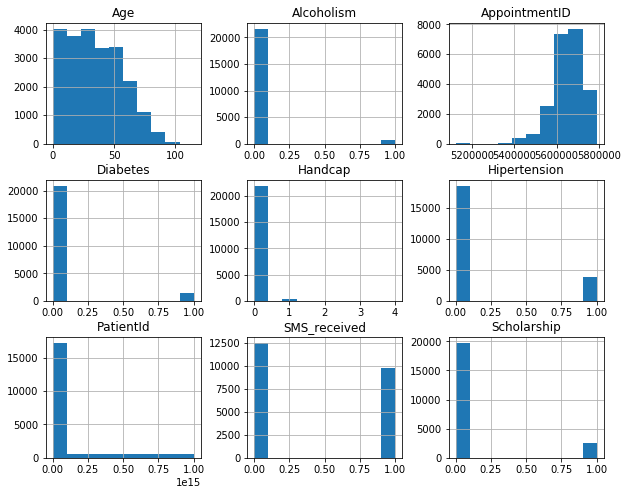

```python
df_No_show.hist(figsize =(10,8));
```

This helps gives a graphical representation of various features for Patients that misssed their appointment.

## Exploratory Data Analysis

### Research Question 1 (How can Scholarship affect Non_Attendance(No_show) of Patients?)

```python
df_No_show.Scholarship.value_counts()
```

```
0    19741
1     2578
Name: Scholarship, dtype: int64
```

This helps get the value count of Patients that have Scholarship or not

```python
def my_function(x,title):
    sns.countplot(x,data = df_No_show, hue = x).set(Title=title)
```

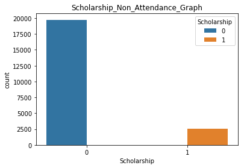

```python
my_function('Scholarship' , 'Scholarship_Non_Attendance_Graph')
```

Here, the two groups of Scholarship was plotted against the values of No-show(Non-Attendance).

### Research Question 2 (what effect can Age have on the Non_Attendance(No_show)of Patients?)

```python
df.Age.describe()
```

```
count    110527.000000
mean         37.088874
std          23.110205
min          -1.000000
25%          18.000000
50%          37.000000
75%          55.000000
max         115.000000
Name: Age, dtype: float64
```

The cell above was performed to help compute the Age into distinct categories that can be represented on the graph.

```
Text(0,0.5,'Average Age group mean')
```

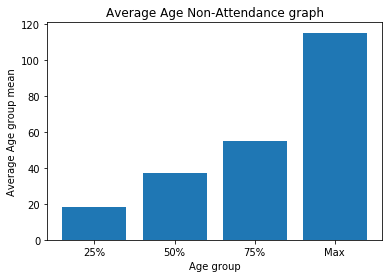

```python
heights = np.array([ 18.000000, 37.000000, 55.000000, 115.000000])
plt.bar([1,2,3,4],heights, tick_label=["25%","50%","75%","Max"])
plt.title('Average Age Non-Attendance graph')
plt.xlabel('Age group')
plt.ylabel('Average Age group mean')
```

### Research Question 3 (Did SMS_received affect attendance(No_show) of Patients?)

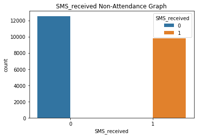

```python
my_function('SMS_received' , 'SMS_received Non-Attendance Graph')
```

This shows a graphical representation of SMS_received in respect to the No_show Patients.

### Research Question 4 (Did Hipertension affect attendance(No_show) of Patients?)

```python
df_No_show['Hipertension'].value_counts()
```

```
0    18547
1     3772
Name: Hipertension, dtype: int64
```

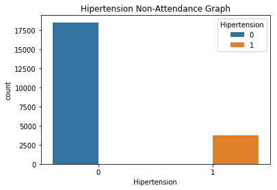

```python
my_function('Hipertension' , 'Hipertension Non-Attendance Graph')
```

The above graph shows the graphical repesentatation of the Value_counts Of Hipertension with respect to the number of Patient that missed their Appointment as shown in the cell before it.

# Comparism of multiple independent variable and dependent variable on different chat.

The codes below shows the count of scholarship and SMS.

```python
SMS_count = df_No_show['SMS_received'].value_counts()
SMS_count
```

```
0    12535
1     9784
Name: SMS_received, dtype: int64
```

```python
Scholarship_count = df_No_show['Scholarship'].value_counts()
Scholarship_count
```

```
0    19741
1     2578
Name: Scholarship, dtype: int64
```

The cell below showed the value_counts between Scholarship and SMS_received. This helps to for better Visualisation and representation of multiple variables(Scholarship and SMS_received) against an dependent variable(No_show)

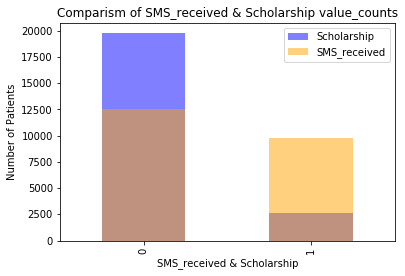

```python
df_No_show['Scholarship'].value_counts().plot(kind='bar', alpha=0.5,color='blue',label ='Scholarship')
df_No_show['SMS_received'].value_counts().plot(kind='bar', alpha=0.5,color='orange',label ='SMS_received')
plt.title('Comparism of SMS_received & Scholarship value_counts')
plt.xlabel('SMS_received & Scholarship')
plt.ylabel('Number of Patients')
plt.legend();
```

## Conclusions

Limitations

In the data record for SMS_received, questions such as: was the phone number of the patient summited?,was it as a result of change of phone number,location?or could the occupation of Patients lead to their absenteeism as these could help proper explanation the cause of absenteeism experienced.

## Submitting your Project

```python
from subprocess import call
call(['python', '-m', 'nbconvert', 'Investigate_a_Dataset.ipynb'])
```

```
0
```